# Juarez-Kathleen - ML Assignment

# 1. Install Package

```r
#install.packages("AmesHousing")
#install.packages("MASS")
#install.packages("earth")
#install.packages("caret")
#install.packages("broom")
#install.packages("leaps")
#install.packages("skimr")
#install.packages("tidyverse")
#install.packages("mgcv")
#install.packages("glmnet")
library(glmnet)
library(mgcv)
library(caret)
library(earth)
library(skimr)
library(dplyr)
library(ggplot2)
library(magrittr)
library(broom)
library(tidyverse)
library(MASS)   # for the Boston dataset
library(leaps)
```

# 2. Data

## 2.1 Boston Housing Data

`medv`: median value of owner-occupied homes in $1000s.

```r
library(MASS)
data("Boston")

head(Boston)
```

|  | crim | zn | indus | chas | nox | rm | age | dis | rad | tax | ptratio | black | lstat | medv |
| --- | --- | --- | --- | --- | --- | --- | --- | --- | --- | --- | --- | --- | --- | --- |
| 1 | 0.00632 | 18 | 2.31 | 0 | 0.538 | 6.575 | 65.2 | 4.0900 | 1 | 296 | 15.3 | 396.90 | 4.98 | 24.0 |
| 2 | 0.02731 | 0 | 7.07 | 0 | 0.469 | 6.421 | 78.9 | 4.9671 | 2 | 242 | 17.8 | 396.90 | 9.14 | 21.6 |
| 3 | 0.02729 | 0 | 7.07 | 0 | 0.469 | 7.185 | 61.1 | 4.9671 | 2 | 242 | 17.8 | 392.83 | 4.03 | 34.7 |
| 4 | 0.03237 | 0 | 2.18 | 0 | 0.458 | 6.998 | 45.8 | 6.0622 | 3 | 222 | 18.7 | 394.63 | 2.94 | 33.4 |
| 5 | 0.06905 | 0 | 2.18 | 0 | 0.458 | 7.147 | 54.2 | 6.0622 | 3 | 222 | 18.7 | 396.90 | 5.33 | 36.2 |
| 6 | 0.02985 | 0 | 2.18 | 0 | 0.458 | 6.430 | 58.7 | 6.0622 | 3 | 222 | 18.7 | 394.12 | 5.21 | 28.7 |

```r
skim(Boston)
```

Data summary

| Name | Boston |
| --- | --- |
| Number of rows | 506 |
| Number of columns | 14 |
| _______________________ |  |
| Column type frequency: |  |
| numeric | 14 |
| ________________________ |  |
| Group variables | None |

**Variable type: numeric**

| skim_variable | n_missing | complete_rate | mean | sd | p0 | p25 | p50 | p75 | p100 | hist |
| --- | --- | --- | --- | --- | --- | --- | --- | --- | --- | --- |
| crim | 0 | 1 | 3.61 | 8.60 | 0.01 | 0.08 | 0.26 | 3.68 | 88.98 | ▇▁▁▁▁ |
| zn | 0 | 1 | 11.36 | 23.32 | 0.00 | 0.00 | 0.00 | 12.50 | 100.00 | ▇▁▁▁▁ |
| indus | 0 | 1 | 11.14 | 6.86 | 0.46 | 5.19 | 9.69 | 18.10 | 27.74 | ▇▆▁▇▁ |
| chas | 0 | 1 | 0.07 | 0.25 | 0.00 | 0.00 | 0.00 | 0.00 | 1.00 | ▇▁▁▁▁ |
| nox | 0 | 1 | 0.55 | 0.12 | 0.38 | 0.45 | 0.54 | 0.62 | 0.87 | ▇▇▆▅▁ |
| rm | 0 | 1 | 6.28 | 0.70 | 3.56 | 5.89 | 6.21 | 6.62 | 8.78 | ▁▂▇▂▁ |
| age | 0 | 1 | 68.57 | 28.15 | 2.90 | 45.02 | 77.50 | 94.07 | 100.00 | ▂▂▂▃▇ |
| dis | 0 | 1 | 3.80 | 2.11 | 1.13 | 2.10 | 3.21 | 5.19 | 12.13 | ▇▅▂▁▁ |
| rad | 0 | 1 | 9.55 | 8.71 | 1.00 | 4.00 | 5.00 | 24.00 | 24.00 | ▇▂▁▁▃ |
| tax | 0 | 1 | 408.24 | 168.54 | 187.00 | 279.00 | 330.00 | 666.00 | 711.00 | ▇▇▃▁▇ |
| ptratio | 0 | 1 | 18.46 | 2.16 | 12.60 | 17.40 | 19.05 | 20.20 | 22.00 | ▁▃▅▅▇ |
| black | 0 | 1 | 356.67 | 91.29 | 0.32 | 375.38 | 391.44 | 396.22 | 396.90 | ▁▁▁▁▇ |
| lstat | 0 | 1 | 12.65 | 7.14 | 1.73 | 6.95 | 11.36 | 16.96 | 37.97 | ▇▇▅▂▁ |
| medv | 0 | 1 | 22.53 | 9.20 | 5.00 | 17.02 | 21.20 | 25.00 | 50.00 | ▂▇▅▁▁ |

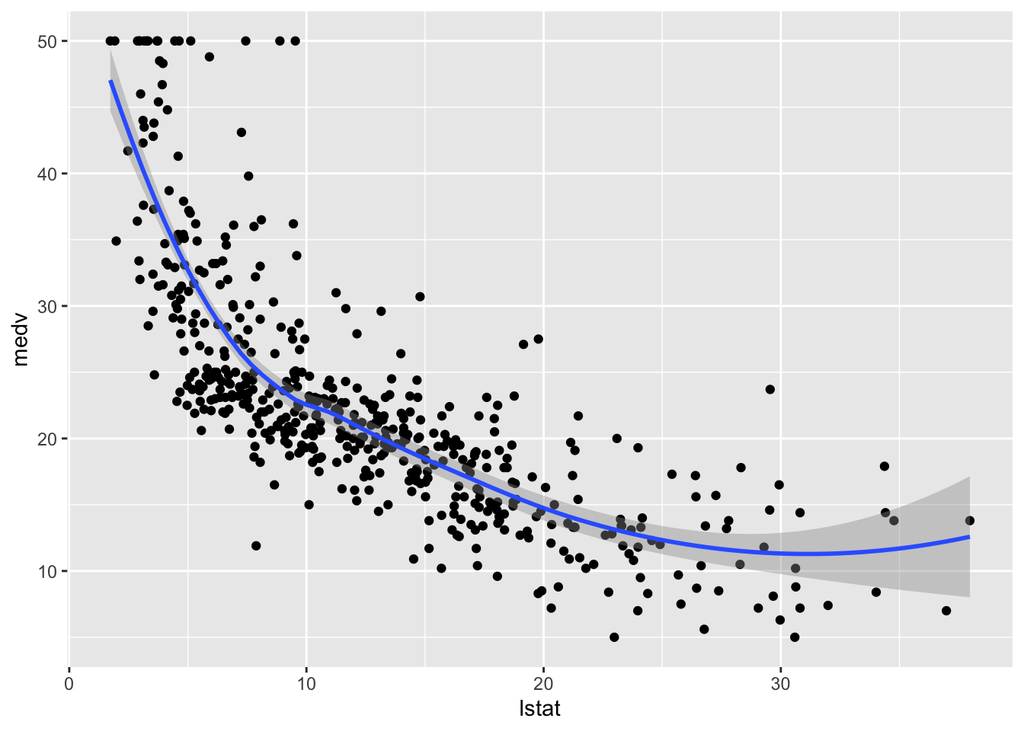

```r
# Can visualize few relationships
ggplot(data = Boston, aes(x=lstat, y=medv)) +
  geom_point () +
  geom_smooth(method="loess")
```

```r
 #lstat= lower status of the population (percent). medv = median value of owner-occupied homes in $1000s.
```

## 2.2 Chicago Housing Data

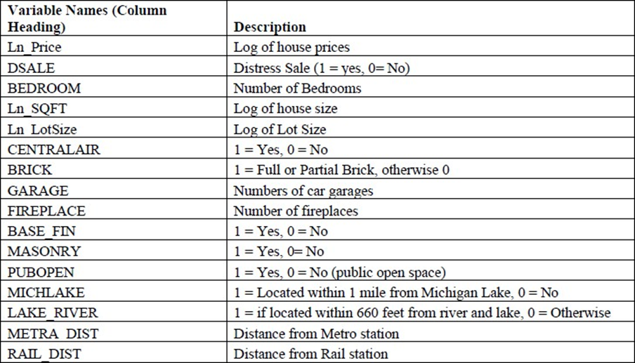

```r
# Chicago Housing Data
library(readr)

chicago <- read_csv("chicago housingdata.csv")

head(chicago)
```

| Ln_Price | DSALE | BEDROOM | Ln_SQFT | Ln_LotSize | CENTRALAIR | BRICK | GARAGE | FIREPLACE | BASE_FIN | MASONRY | PUBOPEN | MICHLAKE | LAKE_RIVER | METRA_DIST | RAIL_DIST |
| --- | --- | --- | --- | --- | --- | --- | --- | --- | --- | --- | --- | --- | --- | --- | --- |
| 11.83138 | 0 | 3 | 6.794587 | 8.031060 | 0 | 0 | 2 | 0 | 1 | 0 | 0 | 0 | 0 | 1.49801 | 0.20677 |
| 11.28978 | 1 | 3 | 6.992096 | 8.039157 | 0 | 1 | 0 | 0 | 1 | 0 | 1 | 0 | 0 | 3.05638 | 0.19410 |
| 12.80902 | 0 | 5 | 7.047517 | 8.300529 | 1 | 1 | 2 | 0 | 0 | 1 | 0 | 0 | 0 | 2.13873 | 0.85084 |
| 12.45293 | 1 | 3 | 7.310550 | 8.499844 | 0 | 1 | 2 | 0 | 1 | 1 | 0 | 0 | 0 | 1.87168 | 1.03969 |
| 13.48909 | 0 | 4 | 7.664816 | 7.783224 | 1 | 1 | 2 | 1 | 0 | 1 | 1 | 0 | 0 | 0.86320 | 0.05104 |
| 12.08391 | 0 | 4 | 7.238497 | 8.383662 | 0 | 1 | 1 | 1 | 1 | 0 | 0 | 0 | 0 | 0.87661 | 0.39791 |

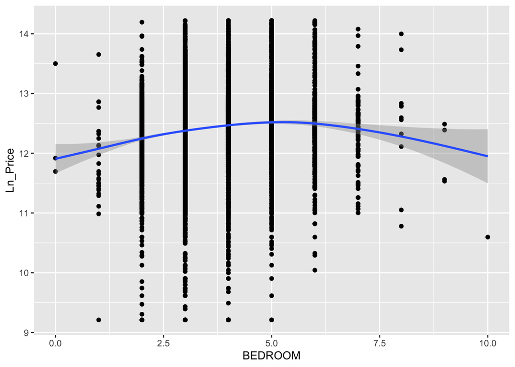

```r
ggplot(chicago,aes(x=BEDROOM, y=Ln_Price)) +
  geom_point () +
  geom_smooth(method="gam")
```

## 2.3 Heart data

Description:

- Age
- Sex (1= male, 0= female)
- ChestPain (1= typical angina, 2= atypical angina, 3= non-anginal pain, 4= asymptotic) RestBP
- Chol
- Fbs (fasting blood sugar)
- RestECG (0 = normal, 1 = having ST-T wave abnormally, 2= left ventricular) CHD (coronary heart disease: 1= yes, 0= no)

```r
library(haven)
heart <-
  read_sav("Heart Data.sav")

View(heart)
```

[output not shown]

# Question 1

**Question 1**

According to your professor, there are three conditions that must be satisfied if one wants to claim variable A causes variable B. What are those, and elaborate on them.

ANSWER: To claim Variable A causes Variable B, three things must be true: A and B must be related, A must happen before B, and there must be no other factors explaining the relationship. When these conditions are met, we can say A causes B.

# 3. Multiple Linear and Logistic Regression

## 3.1 Log-Level Model with Boston Data

```r
# Boston Data
library(broom)

lm(log(medv) ~ ., data=Boston) %>%
  tidy() %>%
  mutate(across(where(is.numeric), ~ round(., 4)))
```

| term | estimate | std.error | statistic | p.value |
| --- | --- | --- | --- | --- |
| (Intercept) | 4.1020 | 0.2043 | 20.0812 | 0.0000 |
| crim | -0.0103 | 0.0013 | -7.8083 | 0.0000 |
| zn | 0.0012 | 0.0005 | 2.1338 | 0.0333 |
| indus | 0.0025 | 0.0025 | 1.0022 | 0.3168 |
| chas | 0.1009 | 0.0345 | 2.9255 | 0.0036 |
| nox | -0.7784 | 0.1529 | -5.0912 | 0.0000 |
| rm | 0.0908 | 0.0167 | 5.4300 | 0.0000 |
| age | 0.0002 | 0.0005 | 0.3983 | 0.6906 |
| dis | -0.0491 | 0.0080 | -6.1486 | 0.0000 |
| rad | 0.0143 | 0.0027 | 5.3725 | 0.0000 |

[output cut: 4 more lines]

**Tip**

Log Linear model

- log(y) = β₀ + β₁x₁ + β₂x₂ + … + ε
  - A **one-unit increase in `xᵢ`** is associated with an **approximately (100 × βᵢ)% change in `y`**, **holding other variables constant**.

## 3.2 Log-Log Model with Chicago Data

```r
# Chicago Housing Data
lm(Ln_Price ~ ., data=chicago) %>%
  tidy() %>%
   mutate(across(where(is.numeric), ~ round(., 4)))
```

| term | estimate | std.error | statistic | p.value |
| --- | --- | --- | --- | --- |
| (Intercept) | 9.4526 | 0.1669 | 56.6266 | 0.0000 |
| DSALE | -0.4032 | 0.0138 | -29.1758 | 0.0000 |
| BEDROOM | -0.0123 | 0.0045 | -2.7281 | 0.0064 |
| Ln_SQFT | 0.4699 | 0.0144 | 32.6707 | 0.0000 |
| Ln_LotSize | -0.0797 | 0.0172 | -4.6449 | 0.0000 |
| CENTRALAIR | 0.2715 | 0.0094 | 28.7647 | 0.0000 |
| BRICK | 0.0098 | 0.0119 | 0.8233 | 0.4103 |
| GARAGE | 0.1020 | 0.0056 | 18.3570 | 0.0000 |
| FIREPLACE | 0.1625 | 0.0073 | 22.3056 | 0.0000 |
| BASE_FIN | -0.0041 | 0.0087 | -0.4776 | 0.6329 |

[output cut: 6 more lines]

**Log Log Model**

Log-Log model

- log(y) = β₀ + β₁log(x₁) + β₂x₂ + … + ε
  - A **1 % increase in `x1`** is associated with an **approximately β1% change in `y`**, **holding other variables constant**.

## 3.3 Functional Forms Summary Table

| **Model Type** | **Formula** | **Interpretation** |
| --- | --- | --- |
| **Log-Linear** | `log(y) ~ x` | A 1-unit increase in `x` → ~**100 × β%** change in `y` |
| **Log-Log** | `log(y) ~ log(x)` | A 1% increase in `x` → ~**β%** change in `y` (**elasticity**) |
| **Linear-Log** | `y ~ log(x)` | A 1% increase in `x` → ~**β ÷ 100** unit change in `y` |
| **Linear** | `y ~ x` | A 1-unit increase in `x` → **β** unit change in `y` |

### 3.3.1 Caveat for log-level model

log(y) = 0.5·x + …

- In the Log-level model, it is only accurate when β is small (say |β| < 0.1). For larger coefficients, the **exponential form** gives the exact percentage change.

When the coefficient (like **0.5**) is **large**, the usual shortcut for interpreting the result isn’t very accurate.

#### **1. Approximate method** (only works well when β is small — like < 0.1):

- Rule of thumb: Multiply the coefficient by 100.

  → So: `0.5 × 100 = 50%`

  → **1 unit increase in x = ~50% increase in y**

#### **2. Exact method** (always accurate):

- Use the formula: (exp(β)−1) x 100

  → So: (exp(.5) x 100≈64.87

  → **1 unit increase in x = ~64.9% increase in y**

If your coefficient is **small** (like 0.05), the **approximate method** (β × 100) is fine.

If your coefficient is **large** (like 0.5 or more), use the **exact method** with `exp(β) - 1`.

```r
(exp(0.1) - 1) * 100
```

```
[1] 10.51709
```

```r
(exp(0.5) - 1) * 100
```

```
[1] 64.87213
```

## 3.4 Logistic model with Heart Data

```r
# Running binary logistic model for heart
m3 <-
  glm(CHD ~ ., family = binomial(link="logit"), data=heart) #CHD (coronary heart disease: 1= yes, 0= no)
tidy(m3) %>%
   mutate(across(where(is.numeric), ~ round(., 4)))
```

| term | estimate | std.error | statistic | p.value |
| --- | --- | --- | --- | --- |
| (Intercept) | -12.0037 | 1.7728 | -6.7710 | 0.0000 |
| Age | 0.0548 | 0.0178 | 3.0728 | 0.0021 |
| Sex | 1.9352 | 0.3494 | 5.5380 | 0.0000 |
| ChestPain | 1.1399 | 0.1708 | 6.6743 | 0.0000 |
| RestBP | 0.0201 | 0.0084 | 2.4019 | 0.0163 |
| Chol | 0.0036 | 0.0028 | 1.3088 | 0.1906 |
| Fbs | -0.1450 | 0.3927 | -0.3692 | 0.7120 |
| RestECG | 0.2629 | 0.1450 | 1.8127 | 0.0699 |

**code explanation**

### code explanation

```
glm(): This fits a generalized linear model.

CHD ~ .: You're modeling CHD (coronary heart disease) as the outcome, using all other variables in the heart dataset as predictors.

family = binomial(link = "logit"): This tells R to run a logistic regression (used when the outcome is binary: 0 or 1).

    Here, CHD = 1 means the person has heart disease.

    CHD = 0 means they don't.

Result: This model estimates how each predictor affects the log-odds of having coronary heart disease.
```

```r
# You can calculate OR and their confidence intervals for interpretation
OR_table <-
 cbind(OR = coef(m3), confint(m3)) %>%
  exp() %>%
  round(3)
```

# 3.5 Boston Data

```r
# Boston Housing Data : Best Subsets Regression

# Load data
data("Boston")

# Fit best subsets regression
best.sub.1 <-
  regsubsets(log(medv) ~ ., data = Boston, nvmax = 10)

# Show summary
summary(best.sub.1)
```

```
Subset selection object
Call: regsubsets.formula(log(medv) ~ ., data = Boston, nvmax = 10)
13 Variables  (and intercept)
        Forced in Forced out
crim        FALSE      FALSE
zn          FALSE      FALSE
indus       FALSE      FALSE
chas        FALSE      FALSE
nox         FALSE      FALSE
rm          FALSE      FALSE
age         FALSE      FALSE
dis         FALSE      FALSE
rad         FALSE      FALSE
tax         FALSE      FALSE
ptratio     FALSE      FALSE
black       FALSE      FALSE
lstat       FALSE      FALSE
1 subsets of each size up to 10
Selection Algorithm: exhaustive
          crim zn  indus chas nox rm  age dis rad tax ptratio black lstat
1  ( 1 )  " "  " " " "   " "  " " " " " " " " " " " " " "     " "   "*"
2  ( 1 )  " "  " " " "   " "  " " " " " " " " " " " " "*"     " "   "*"
3  ( 1 )  "*"  " " " "   " "  " " " " " " " " " " " " "*"     " "   "*"
4  ( 1 )  "*"  " " " "   " "  " " "*" " " " " " " " " "*"     " "   "*"
5  ( 1 )  "*"  " " " "   " "  " " "*" " " "*" " " " " "*"     " "   "*"
6  ( 1 )  "*"  " " " "   " "  "*" "*" " " "*" " " " " "*"     " "   "*"
7  ( 1 )  "*"  " " " "   " "  "*" "*" " " "*" " " " " "*"     "*"   "*"
8  ( 1 )  "*"  " " " "   " "  "*" "*" " " "*" "*" "*" "*"     " "   "*"
9  ( 1 )  "*"  " " " "   " "  "*" "*" " " "*" "*" "*" "*"     "*"   "*"
10  ( 1 ) "*"  " " " "   "*"  "*" "*" " " "*" "*" "*" "*"     "*"   "*"
```

**code explanation**

## code explanation

### `regsubsets()`

- This function is from the **`leaps`** package.
- It performs **best subsets regression**, which tries **all possible combinations** of predictors to find the **best model** based on a criterion (like adjusted R², BIC, or Cp).
- It’s a tool for **variable selection**.

### `log(medv) ~ .`

- The **response variable** is `log(medv)` (log of median home value).
- The `.` means use **all other variables** in the `Boston` dataset as predictors.

`nvmax = 10`

- This limits the search to models with **up to 10 predictors**
- Useful for controlling complexity and computation time.

```r
reg.summary <-
  summary(best.sub.1)

reg.summary$rsq
```

```
 [1] 0.6480799 0.6948709 0.7177671 0.7426593 0.7505194 0.7650280 0.7708418
 [8] 0.7764742 0.7834085 0.7874240
```

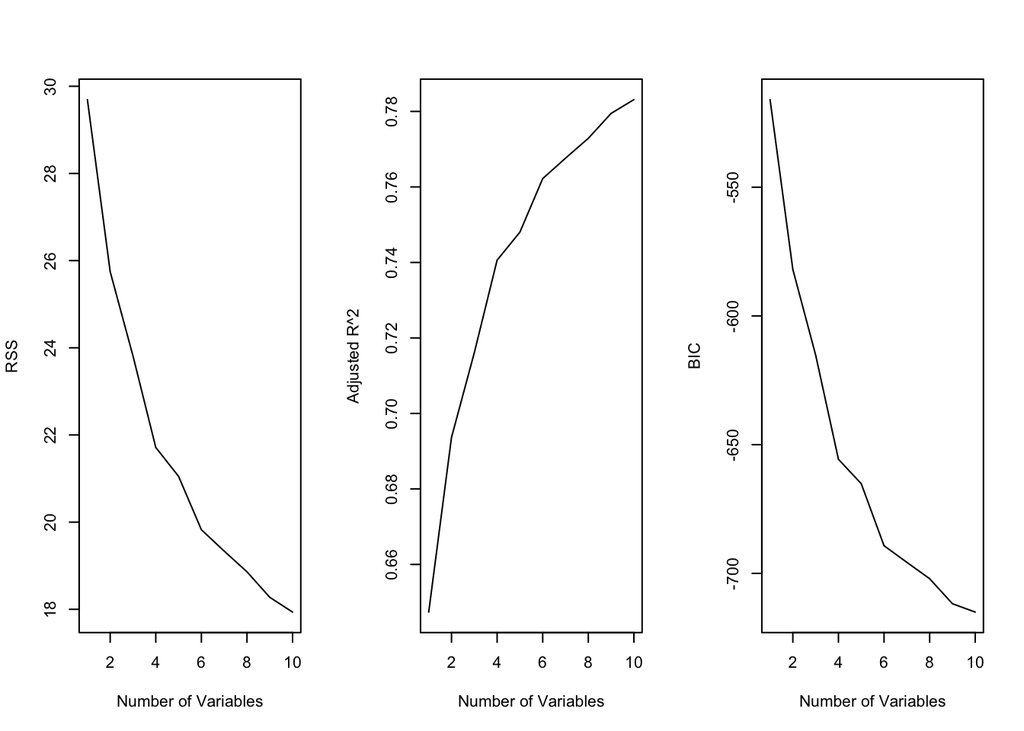

```r
par(mfrow=c(1,3))

plot(reg.summary$rss, xlab='Number of Variables', ylab='RSS', type='l')
# rss = residual sum of squares

plot(reg.summary$adjr2, xlab='Number of Variables', ylab='Adjusted R^2', type='l')

plot(reg.summary$bic, xlab='Number of Variables', ylab='BIC', type='l')
```

**code explanation**

```
par can be used to set or query graphical parameters. Parameters can be set by specifying them as arguments to par in tag = value form, or by passing them as a list of tagged values
```

### 3.5.2

```r
# Chicago Housing Data : Best Subsets Regression
best.sub. <-
  regsubsets(Ln_Price ~ ., data = chicago, nvmax=10)

summary(best.sub.1)
```

```
Subset selection object
Call: regsubsets.formula(log(medv) ~ ., data = Boston, nvmax = 10)
13 Variables  (and intercept)
        Forced in Forced out
crim        FALSE      FALSE
zn          FALSE      FALSE
indus       FALSE      FALSE
chas        FALSE      FALSE
nox         FALSE      FALSE
rm          FALSE      FALSE
age         FALSE      FALSE
dis         FALSE      FALSE
rad         FALSE      FALSE
tax         FALSE      FALSE
ptratio     FALSE      FALSE
black       FALSE      FALSE
lstat       FALSE      FALSE
1 subsets of each size up to 10
Selection Algorithm: exhaustive
          crim zn  indus chas nox rm  age dis rad tax ptratio black lstat
1  ( 1 )  " "  " " " "   " "  " " " " " " " " " " " " " "     " "   "*"
2  ( 1 )  " "  " " " "   " "  " " " " " " " " " " " " "*"     " "   "*"
3  ( 1 )  "*"  " " " "   " "  " " " " " " " " " " " " "*"     " "   "*"
4  ( 1 )  "*"  " " " "   " "  " " "*" " " " " " " " " "*"     " "   "*"
5  ( 1 )  "*"  " " " "   " "  " " "*" " " "*" " " " " "*"     " "   "*"
6  ( 1 )  "*"  " " " "   " "  "*" "*" " " "*" " " " " "*"     " "   "*"
7  ( 1 )  "*"  " " " "   " "  "*" "*" " " "*" " " " " "*"     "*"   "*"
8  ( 1 )  "*"  " " " "   " "  "*" "*" " " "*" "*" "*" "*"     " "   "*"
9  ( 1 )  "*"  " " " "   " "  "*" "*" " " "*" "*" "*" "*"     "*"   "*"
10  ( 1 ) "*"  " " " "   "*"  "*" "*" " " "*" "*" "*" "*"     "*"   "*"
```

```r
reg.summary <-
  summary(best.sub.1)

reg.summary$rsq
```

```
 [1] 0.6480799 0.6948709 0.7177671 0.7426593 0.7505194 0.7650280 0.7708418
 [8] 0.7764742 0.7834085 0.7874240
```

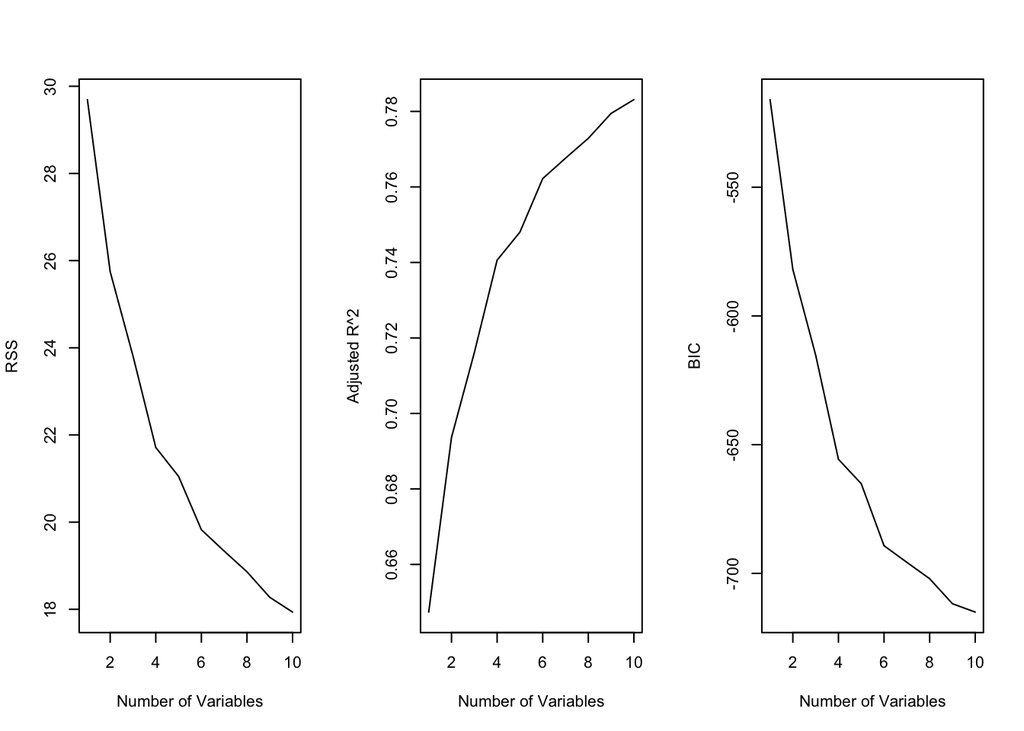

```r
par(mfrow=c(1,3))

plot(reg.summary$rss, xlab='Number of Variables', ylab='RSS', type='l')
plot(reg.summary$adjr2, xlab='Number of Variables', ylab='Adjusted R^2', type='l')
plot(reg.summary$bic, xlab='Number of Variables', ylab='BIC', type='l')
```

# Question 2

**Question 2**

What is internal validity? Explain why the existence of causality among variables in a study enhances the internal validity of the study findings

ANSWER: Internal validity just means a study shows that one thing really causes another, with no outside factors messing things up. When causality is clear, it makes the results more trustworthy because we know the changes are due to the variables we’re studying, not something else.

Which research design is best in general for internal validity? Explain why.

ANSWER: The best research design for internal validity is an experimental design, especially randomized controlled trials (RCTs). This is because in RCTs, participants are randomly assigned to different groups, which helps prevent bias and control for other factors. This way, researchers can be sure that any changes they see are actually due to the treatment and not something else.

# Question 3

**Question 3**

Compare and contrast (1) experimental design and (2) survey design in terms of (1) what they are, (2) internal validity, and (3) external validity. How can you improve external validity for experiments?

# 4. MARS - Multivariate Adaptive Regression Splines:

## 4.1 MARS with Boston Data

```r
# Sample splitting into Train and Test

set.seed(2022)
index <- sample(1:nrow(Boston), size = floor(0.7*nrow(Boston)), replace = FALSE)
train <- Boston[index,]
test <- Boston[-index,]
dim(train)
```

```
[1] 354  14
```

```r
dim(test)
```

```
[1] 152  14
```

```r
dim(Boston)
```

```
[1] 506  14
```

```r
x <- train[, -14]
y <- train[, 14]
dim(x)
```

```
[1] 354  13
```

```r
dim(y)
```

```r
y |> as_tibble() |> dim()
```

```
[1] 354   1
```

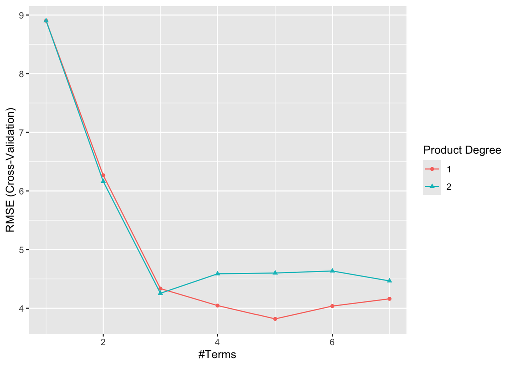

```r
library(caret)
# Create parameter tuning grid
parameter_grid <- floor(expand.grid(degree = 1:2, nprune = seq(2:8)))

# Perform cross-validation using caret package
cv_mars_boston <- train(x=x, y=y,
                        method ='earth',
                        metric='RMSE',
                        trControl = trainControl(method='cv', number = 10),
                        tuneGrid=parameter_grid)

ggplot(cv_mars_boston)
```

```r
cv_mars_boston
```

```
Multivariate Adaptive Regression Spline

354 samples
 13 predictor

No pre-processing
Resampling: Cross-Validated (10 fold)
Summary of sample sizes: 319, 318, 318, 319, 318, 319, ...
Resampling results across tuning parameters:

  degree  nprune  RMSE      Rsquared   MAE
  1       1       8.903001        NaN  6.582072
  1       2       6.267309  0.5225565  4.433939
  1       3       4.335597  0.7518425  3.113719
  1       4       4.045712  0.7853128  2.881418
  1       5       3.818736  0.8046998  2.718358
  1       6       4.037093  0.7808475  2.837522
  1       7       4.160753  0.7692407  2.925034
  2       1       8.903001        NaN  6.582072
  2       2       6.162372  0.5345639  4.523257
  2       3       4.254899  0.7630432  3.017795
  2       4       4.587324  0.7227562  3.039501
  2       5       4.600703  0.7155766  3.079109
  2       6       4.635297  0.7127119  3.032599
  2       7       4.466139  0.7410407  2.971605

RMSE was used to select the optimal model using the smallest value.
The final values used for the model were nprune = 5 and degree = 1.
```

```r
mars_predict <-
  predict(object=cv_mars_boston$finalModel,
                        newdata = test)
mars_predict
```

```
               y
  [1,] 22.669581
  [2,] 11.979837
  [3,] 19.624241
  [4,] 20.452434
  [5,] 21.104788
  [6,] 22.105770
  [7,] 13.502092
  [8,] 17.786057
  [9,] 14.872484
 [10,] 17.202150
 [11,] 15.730469
 [12,] 21.066282
 [13,] 21.433848
 [14,] 24.852375
```

[output cut: 138 more lines]

```r
mean(abs(test$medv - mars_predict))
```

```
[1] 3.269102
```

```r
# Multivariate Adaptive Regression Splines
mars.1 <-
  earth(medv ~ ., degree=1, nprune = 5, data=Boston) #nprune: maximum no. of terms including intercept.

summary(mars.1)
```

```
Call: earth(formula=medv~., data=Boston, degree=1, nprune=5)

                coefficients
(Intercept)       26.2175309
h(rm-6.431)        8.3739605
h(ptratio-14.7)   -0.6260660
h(6.12-lstat)      2.6469864
h(lstat-6.12)     -0.5536614

Selected 5 of 24 terms, and 3 of 13 predictors (nprune=5)
Termination condition: Reached nk 27
Importance: rm, lstat, ptratio, crim-unused, zn-unused, indus-unused, ...
Number of terms at each degree of interaction: 1 4 (additive model)
GCV 18.75408    RSS 9154.991    GRSq 0.778724    RSq 0.7856792
```

```
 plotmo grid:    crim zn indus chas   nox     rm  age     dis rad tax ptratio
              0.25651  0  9.69    0 0.538 6.2085 77.5 3.20745   5 330   19.05
  black lstat
 391.44 11.36
```

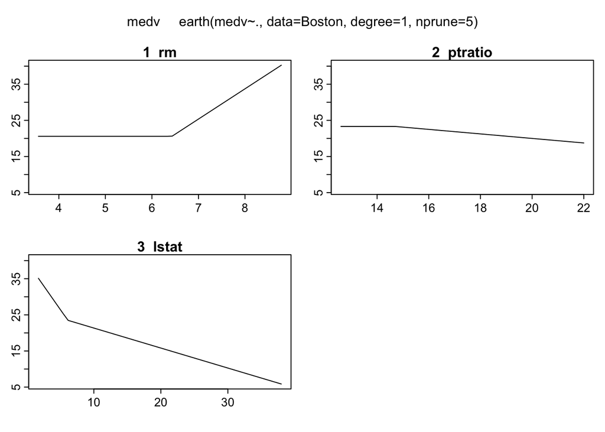

```r
plotmo(mars.1) # out of 13 variables, only 3 were picked.
```

```r
mars.2 <-
  earth(log(medv) ~ ., degree=1, nprune = 7, data=Boston)
summary(mars.2)
```

```
Call: earth(formula=log(medv)~., data=Boston, degree=1, nprune=7)

                coefficients
(Intercept)       2.79856060
h(23.6482-crim)   0.01912623
h(nox-0.624)     -0.48348593
h(rm-6.405)       0.33815948
h(1.4165-dis)     2.76852577
h(ptratio-18.6)  -0.06002929
h(lstat-6.12)    -0.02619073

Selected 7 of 24 terms, and 6 of 13 predictors (nprune=7)
Termination condition: Reached nk 27
Importance: lstat, rm, crim, dis, ptratio, nox, zn-unused, indus-unused, ...
Number of terms at each degree of interaction: 1 6 (additive model)
GCV 0.03325566    RSS 15.97382    GRSq 0.8013556    RSq 0.810684
```

```
 plotmo grid:    crim zn indus chas   nox     rm  age     dis rad tax ptratio
              0.25651  0  9.69    0 0.538 6.2085 77.5 3.20745   5 330   19.05
  black lstat
 391.44 11.36
```

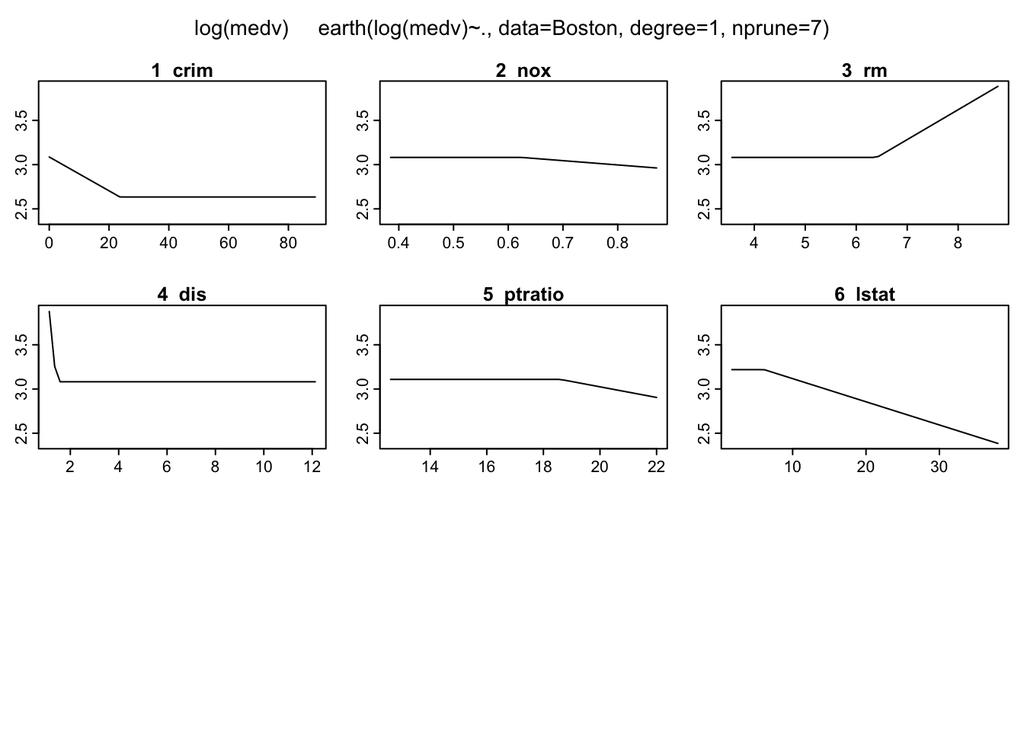

```r
plotmo(mars.2)
```

# 5. GAM; Regression Model

- **`s()`**
  - `s(variable)` tells `mgcv::gam()` to fit a **smooth function** (usually a spline) for that predictor.
  - Instead of forcing a straight-line relationship (like in linear regression), it lets the model **learn a smooth curve** that best fits the data.

```
Family: gaussian
Link function: identity

Formula:
log(medv) ~ s(crim) + s(rm) + s(dis) + s(ptratio) + s(lstat)

Parametric coefficients:
            Estimate Std. Error t value Pr(>|t|)
(Intercept) 3.034513   0.007683     395   <2e-16 ***
---
Signif. codes:  0 '***' 0.001 '**' 0.01 '*' 0.05 '.' 0.1 ' ' 1

Approximate significance of smooth terms:
             edf Ref.df      F  p-value
s(crim)    2.280  2.833 42.085  < 2e-16 ***
s(rm)      4.577  5.685 14.436  < 2e-16 ***
s(dis)     8.632  8.958  7.176  < 2e-16 ***
s(ptratio) 3.227  3.983  8.352 1.98e-06 ***
s(lstat)   5.331  6.503 46.791  < 2e-16 ***
---
Signif. codes:  0 '***' 0.001 '**' 0.01 '*' 0.05 '.' 0.1 ' ' 1

R-sq.(adj) =  0.821   Deviance explained =   83%
GCV = 0.031426  Scale est. = 0.02987   n = 506
```

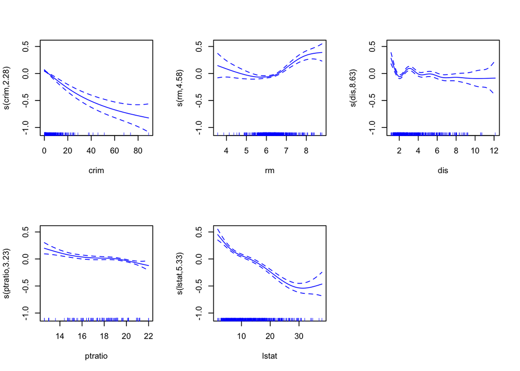

```r
# Regression Model

# You can quickly check the relationship: whether linear or non-linear

library(mgcv)

gam.1 <-
  gam(log(medv)~ s(crim) + s(rm) + s(dis) + s(ptratio) + s(lstat), data=Boston) # s(): Defining smooths in GAM formulae: polynominal

par(mfrow=c(2,3))
plot(gam.1, se=TRUE, col="blue")

summary(gam.1)
```

**summary**

- Tests if the smoothingng non-linear effect adds contributions to the model.

[output not shown]

- Tests if the non-linear effect is significant

[output not shown]

## 5.2 GAM; Classification Model (Your turn):

```r
library(haven)
heart <- read_sav("Heart Data.sav")
```

```r
library(mgcv)

gam2 <-
  mgcv::gam(I(CHD)~ Age + Sex + ChestPain + RestBP + Chol + RestECG, family = binomial, data=heart)

summary(gam2)
```

```
Family: binomial
Link function: logit

Formula:
I(CHD) ~ Age + Sex + ChestPain + RestBP + Chol + RestECG

Parametric coefficients:
              Estimate Std. Error z value Pr(>|z|)
(Intercept) -11.949283   1.765995  -6.766 1.32e-11 ***
Age           0.054204   0.017739   3.056  0.00225 **
Sex           1.926348   0.348376   5.530 3.21e-08 ***
ChestPain     1.142298   0.170696   6.692 2.20e-11 ***
RestBP        0.019700   0.008307   2.372  0.01772 *
Chol          0.003673   0.002769   1.326  0.18470
RestECG       0.260817   0.144880   1.800  0.07182 .
---
Signif. codes:  0 '***' 0.001 '**' 0.01 '*' 0.05 '.' 0.1 ' ' 1


R-sq.(adj) =  0.334   Deviance explained = 27.4%
UBRE = 0.047063  Scale est. = 1         n = 303
```

```r
par(mfrow=c(2,3))
plot(gam2, se=TRUE, col="blue")
```

[output not shown]

```r
gam3 <-
  gam(I(CHD)~ s(Age) + Sex + ChestPain + s(RestBP) + s(Chol) + RestECG, family = binomial, data=heart)
#summary(gam3)
```

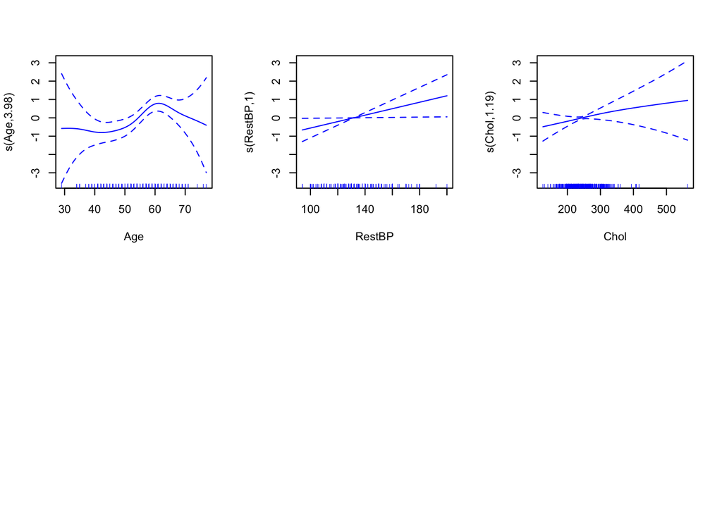

```r
par(mfrow=c(2,3))
plot(gam3, se=TRUE, col="blue")
```

```r
anova(gam2, gam3, test ="Chisq")
```

|  | Resid. Df | Resid. Dev | Df | Deviance | Pr(>Chi) |
| --- | --- | --- | --- | --- | --- |
| 1 | 296.0000 | 303.2601 | NA | NA | NA |
| 2 | 291.6389 | 293.1331 | 4.361126 | 10.12704 | 0.04882151 |

```r
BIC(gam2)
```

```
[1] 343.2563
```

```r
BIC(gam3)
```

```
[1] 351.2447
```

# 6. Regularization

## 6.1 Lasso & Ridge using glmnet with crime data

```r
library(readr)
data <- read_csv("crime.csv")
View(crime_data)
```

[output not shown]

```r
skim(data)
```

Data summary

| Name | data |
| --- | --- |
| Number of rows | 1994 |
| Number of columns | 96 |
| _______________________ |  |
| Column type frequency: |  |
| numeric | 96 |
| ________________________ |  |
| Group variables | None |

**Variable type: numeric**

| skim_variable | n_missing | complete_rate | mean | sd | p0 | p25 | p50 | p75 | p100 | hist |
| --- | --- | --- | --- | --- | --- | --- | --- | --- | --- | --- |
| population | 0 | 1 | 0.06 | 0.13 | 0 | 0.01 | 0.02 | 0.05 | 1 | ▇▁▁▁▁ |
| householdsize | 0 | 1 | 0.46 | 0.16 | 0 | 0.35 | 0.44 | 0.54 | 1 | ▁▇▇▂▁ |
| racepctblack | 0 | 1 | 0.18 | 0.25 | 0 | 0.02 | 0.06 | 0.23 | 1 | ▇▁▁▁▁ |
| racePctWhite | 0 | 1 | 0.75 | 0.24 | 0 | 0.63 | 0.85 | 0.94 | 1 | ▁▁▂▃▇ |
| racePctAsian | 0 | 1 | 0.15 | 0.21 | 0 | 0.04 | 0.07 | 0.17 | 1 | ▇▁▁▁▁ |
| racePctHisp | 0 | 1 | 0.14 | 0.23 | 0 | 0.01 | 0.04 | 0.16 | 1 | ▇▁▁▁▁ |
| agePct12t21 | 0 | 1 | 0.42 | 0.16 | 0 | 0.34 | 0.40 | 0.47 | 1 | ▁▇▆▁▁ |
| agePct12t29 | 0 | 1 | 0.49 | 0.14 | 0 | 0.41 | 0.48 | 0.54 | 1 | ▁▃▇▁▁ |
| agePct16t24 | 0 | 1 | 0.34 | 0.17 | 0 | 0.25 | 0.29 | 0.36 | 1 | ▁▇▁▁▁ |
| agePct65up | 0 | 1 | 0.42 | 0.18 | 0 | 0.30 | 0.42 | 0.53 | 1 | ▂▇▇▂▁ |
| numbUrban | 0 | 1 | 0.06 | 0.13 | 0 | 0.00 | 0.03 | 0.07 | 1 | ▇▁▁▁▁ |
| pctUrban | 0 | 1 | 0.70 | 0.44 | 0 | 0.00 | 1.00 | 1.00 | 1 | ▃▁▁▁▇ |
| medIncome | 0 | 1 | 0.36 | 0.21 | 0 | 0.20 | 0.32 | 0.49 | 1 | ▆▇▅▂▁ |
| pctWWage | 0 | 1 | 0.56 | 0.18 | 0 | 0.44 | 0.56 | 0.69 | 1 | ▁▃▇▆▂ |
| pctWFarmSelf | 0 | 1 | 0.29 | 0.20 | 0 | 0.16 | 0.23 | 0.37 | 1 | ▇▇▂▁▁ |
| pctWInvInc | 0 | 1 | 0.50 | 0.18 | 0 | 0.37 | 0.48 | 0.62 | 1 | ▁▆▇▅▁ |
| pctWSocSec | 0 | 1 | 0.47 | 0.17 | 0 | 0.35 | 0.48 | 0.58 | 1 | ▁▅▇▃▁ |
| pctWPubAsst | 0 | 1 | 0.32 | 0.22 | 0 | 0.14 | 0.26 | 0.44 | 1 | ▇▇▃▂▁ |
| pctWRetire | 0 | 1 | 0.48 | 0.17 | 0 | 0.36 | 0.47 | 0.58 | 1 | ▁▆▇▃▁ |
| medFamInc | 0 | 1 | 0.38 | 0.20 | 0 | 0.23 | 0.33 | 0.48 | 1 | ▃▇▅▂▁ |
| perCapInc | 0 | 1 | 0.35 | 0.19 | 0 | 0.22 | 0.30 | 0.43 | 1 | ▃▇▃▁▁ |
| whitePerCap | 0 | 1 | 0.37 | 0.19 | 0 | 0.24 | 0.32 | 0.44 | 1 | ▂▇▃▁▁ |
| blackPerCap | 0 | 1 | 0.29 | 0.17 | 0 | 0.17 | 0.25 | 0.38 | 1 | ▇▇▃▁▁ |
| indianPerCap | 0 | 1 | 0.20 | 0.16 | 0 | 0.11 | 0.17 | 0.25 | 1 | ▇▃▁▁▁ |
| AsianPerCap | 0 | 1 | 0.32 | 0.20 | 0 | 0.19 | 0.28 | 0.40 | 1 | ▅▇▂▁▁ |
| HispPerCap | 0 | 1 | 0.39 | 0.18 | 0 | 0.26 | 0.34 | 0.48 | 1 | ▂▇▅▁▁ |
| NumUnderPov | 0 | 1 | 0.06 | 0.13 | 0 | 0.01 | 0.02 | 0.05 | 1 | ▇▁▁▁▁ |
| PctPopUnderPov | 0 | 1 | 0.30 | 0.23 | 0 | 0.11 | 0.25 | 0.45 | 1 | ▇▅▃▁▁ |
| PctLess9thGrade | 0 | 1 | 0.32 | 0.21 | 0 | 0.16 | 0.27 | 0.42 | 1 | ▇▇▃▁▁ |
| PctNotHSGrad | 0 | 1 | 0.38 | 0.20 | 0 | 0.23 | 0.36 | 0.51 | 1 | ▅▇▆▂▁ |

[output cut: 66 more lines]

```r
#separate x and y
xdata <-
  model.matrix(ViolentCrimesPerPop ~ ., crime_data)[,-1] # model.matrix creates a design (or model) matrix, e.g., by expanding factors to a set of dummy variables (depending on the contrasts) and expanding interactions similarly. [,-1]: take out y variable
```

[output not shown]

```r
dim(xdata)
```

[output not shown]

```r
head(xdata)
```

[output not shown]

```r
names(xdata)
```

[output not shown]

```r
ydata <-  data$ViolentCrimesPerPop

# Random split of data
set.seed(340)
itrain <- sample(1:nrow(data), nrow(data)*0.5)
length(itrain)
```

```
[1] 997
```

```r
itest <- (-itrain)


#separate into training and test data
xtrain = xdata[itrain,]
```

[output not shown]

```r
ytrain = ydata[itrain]

xtest = xdata[itest,]
```

[output not shown]

```r
ytest = ydata[itest]
```

### 6.1.1 Fitting Lasso, alpha = 1 Crime Data

- Lasso regularization penalizes the size of coefficients, and the penalty strength is controlled by λ.
- High λ = stronger shrinkage → simpler model (more coefficients shrunk to 0).
- `cv.glmnet(...)` runs **Lasso regression** (`alpha = 1`) with 10-fold cross-validation.
- `type.measure = "mse"`: Uses **Mean Squared Error** as the evaluation metric.
- `standardize = TRUE` by default: Each predictor is standardized to mean 0 and sd 1 before fitting

```r
library(glmnet)
# Step 1: Create a grid of λ (lambda) values
# By default glmnet uses lambda = 10^10 =10,000,000,000  and 10^-2 = 0.01
# present plots in log scale
grid <- 10^seq(5,-5, length=1000) # grid,

# Step 2: Run 10-fold cross-validation to find optimal λ
set.seed(123)
cv.lasso <- cv.glmnet(xtrain, ytrain, alpha=1, lambda=grid,
                     nfolds=10, type.measure = "mse")
```

[output not shown]

```r
# default setting is standardize = True

# Step 3: Plot the cross-validation results
par(mfrow=c(1,1))
plot(cv.lasso)
```

[output not shown]

```r
cv.lasso
```

[output not shown]

```r
# Step 4: Extract optimal λ values
lambda1 <- cv.lasso$lambda.min # Best model (smallest MSE)
```

[output not shown]

```r
lambda2 <- cv.lasso$lambda.1se # Simpler model (within 1 SE of best)
```

[output not shown]

```r
lambda1
```

[output not shown]

```r
lambda2
```

[output not shown]

```r
# Step 5: Fit models at both λ values
fit.min <-  glmnet(xtrain, ytrain, alpha=1, lambda = lambda1)
```

[output not shown]

```r
coef(fit.min)
```

[output not shown]

```r
fit.1se <-
  glmnet(xtrain, ytrain, alpha=1, lambda = lambda2)
```

[output not shown]

```r
coef(fit.1se)
```

[output not shown]

```r
# Step 6: Predict on test data and calculate MSE
lasso.yhat <-  predict(fit.min, s=lambda1, newx=xtest)
```

[output not shown]

```r
mean((lasso.yhat - ytest)^2)
```

[output not shown]

```r
lasso.yhat <-  predict(fit.1se, s=lambda2, newx=xtest)
```

[output not shown]

```r
mean((lasso.yhat - ytest)^2)
```

[output not shown]

```r
# Step 7: converting sparse matrix to matrix and to data frame
coef(fit.min) %>% as.matrix() %>% as.data.frame() %>%
  filter(s0 !=0)
```

[output not shown]

```r
coef(fit.1se) %>% as.matrix() %>% as.data.frame() %>%
  filter(s0 !=0)
```

[output not shown]

```r
# Step 8: Fit Lasso without cross-validation
cv.lasso_min <- glmnet(x=xtrain, y=ytrain, alpha=1)
```

[output not shown]

```r
plot(cv.lasso_min, xvar = "lambda")
```

[output not shown]

```r
abline(v = -log(cv.lasso$lambda.min), col = "red", lty = "dashed")
```

[output not shown]

```r
abline(v = -log(cv.lasso$lambda.1se), col = "red", lty = "dashed")
```

[output not shown]

**note**

| Function | Cross-validation? | Purpose |
| --- | --- | --- |
| `glmnet(...)` | ❌ No | Lasso path |
| `cv.glmnet(...)` | ✅ Yes | Finds optimal λ via CV |

### 6.1.2

```r
# find lamda via cross validiation.

grid = 10^seq(5,-5, length=1000) # grid,
set.seed(123)
cv.ridge = cv.glmnet(xtrain, ytrain, alpha=0, lambda=grid,
                     nfolds=10, type.measure = "mse")
```

[output not shown]

```r
# alpha = 0  Ridge; default setting is standardize = True

plot(cv.ridge)
```

[output not shown]

```r
cv.ridge
```

[output not shown]

```r
lambda1 <-  cv.ridge$lambda.min
```

[output not shown]

```r
lambda2 <- cv.ridge$lambda.1se
```

[output not shown]

```r
lambda1
```

[output not shown]

```r
lambda2
```

[output not shown]

```r
fit.min <-  glmnet(xtrain, ytrain, alpha=0, lambda=lambda1)
```

[output not shown]

```r
coef(fit.min)
```

[output not shown]

## 6.2 Regularization using AmesHosing Data: Data Preparation (Your Turn)

```r
# AmesHousing::make_ames() - processed version of the data
data("ames_raw")
head(ames_raw)
```

[output not shown]

```r
set.seed(123)
ames_split <- initial_split(AmesHousing::make_ames(), prop = .7, strata = "Sale_Price")
```

[output not shown]

```r
ames_train <- training(ames_split)
```

[output not shown]

```r
ames_test  <- testing(ames_split)
```

[output not shown]

```r
lm(Sale_Price ~ Gr_Liv_Area + TotRms_AbvGrd, data = ames_train) # show multi colinearity
```

[output not shown]

```r
# Create training and testing feature model matrices and response vectors.
# we use model.matrix(...)[, -1] to discard the intercept

ames_train_x <- model.matrix(Sale_Price ~ ., ames_train)[, -1]
```

[output not shown]

```r
ames_train_y <- log(ames_train$Sale_Price)
```

[output not shown]

```r
ames_test_x <- model.matrix(Sale_Price ~ ., ames_test)[, -1]
```

[output not shown]

```r
ames_test_y <- log(ames_test$Sale_Price)
```

[output not shown]

```r
# (ames_train_x)  What is the dimension of of your feature matrix?
dim(ames_train_x)
```

[output not shown]

## 6.3 Regularization - classification, Heart Data, Preparation

```r
# Classification model
heart
```

| Age | Sex | ChestPain | RestBP | Chol | Fbs | RestECG | CHD |
| --- | --- | --- | --- | --- | --- | --- | --- |
| 63 | 1 | 1 | 145 | 233 | 1 | 2 | 0 |
| 67 | 1 | 4 | 160 | 286 | 0 | 2 | 1 |
| 67 | 1 | 4 | 120 | 229 | 0 | 2 | 1 |
| 37 | 1 | 3 | 130 | 250 | 0 | 0 | 0 |
| 41 | 0 | 2 | 130 | 204 | 0 | 2 | 0 |
| 56 | 1 | 2 | 120 | 236 | 0 | 0 | 0 |
| 62 | 0 | 4 | 140 | 268 | 0 | 2 | 1 |
| 57 | 0 | 4 | 120 | 354 | 0 | 0 | 0 |
| 63 | 1 | 4 | 130 | 254 | 0 | 2 | 1 |
| 53 | 1 | 4 | 140 | 203 | 1 | 2 | 1 |

[output cut: 293 more lines]

```r
#separate x and y
xdata <-  model.matrix(CHD ~ ., data)[,-1]
```

[output not shown]

```r
ydata <-  as.factor(data$CHD)

# Random split of data
set.seed(340)
itrain <- sample(1:nrow(data), nrow(data)*0.6)
itest <- (-itrain)


#separate into training and test data
xtrain = xdata[itrain,]
```

[output not shown]

```r
ytrain = ydata[itrain]

xtest = xdata[itest,]
```

[output not shown]

```r
ytest = ydata[itest]
```

```r
grid = 10^seq(5,-5, length=500) # grid,
set.seed(123)
cv.lasso = cv.glmnet(xtrain, as.factor(ytrain), alpha=1, lambda=grid,
                     nfolds=10, family = "binomial", type.measure = "class")
```

[output not shown]

```r
# type.measure = "response" gives the probabilities
# type.measure = "class" provide 0 and 1 based on predicted probabilities


plot(cv.lasso)
```

[output not shown]

```r
# Plot
plot(fit.heart, xvar = "lambda", label = TRUE)
```

[output not shown]

```r
abline(v = -log(cv.lasso$lambda.min), col = "red", lty = "dashed")
```

[output not shown]

```r
abline(v = -log(cv.lasso$lambda.1se), col = "red", lty = "dashed")
```

[output not shown]

```r
lasso.yhat <-  predict(fit.heart, s=lambda2, newx=xtest, type = "class")
```

[output not shown]

```r
ab <- cbind(lasso.yhat,as.data.frame(ytest))
```

[output not shown]

```r
table(ab$ytest, ab$`s=0.04648734`)
```

[output not shown]

```r
mean(ab$ytest == ab$`s=0.04648734`) #actual == predicted
```

[output not shown]

# Question 4: Regularization

**Question 4. 1**

What is regularization? Why is it better than the Ordinary Least Squares method?

ANSWER:Regularization is a way to keep a regression model from getting too complicated by adding a penalty for large coefficients. It’s better than OLS because OLS can lead to overfitting, where the model is too closely fitted to the training data and doesn’t work well on new data. Regularization helps make the model simpler and more reliable, focusing on the most important predictors.

**Question 4.2**

Compare and contrast Ridge and Lasso regressions. What are the similarities and differences? Under what circumstances does each regularization work better?

ANSWER: Ridge and Lasso are both ways to prevent overfitting by adding penalties to the model, but they do it differently. **Ridge** shrinks all coefficients, keeping all variables in the model but making them less important. **Lasso**, on the other hand, can shrink some coefficients to zero, effectively removing less important variables. **Ridge** is better when you have many relevant predictors and don’t want to eliminate any, while **Lasso** is great when you think only a few predictors matter and want to simplify the model.

**Question 4.3**

What is cross-validation? Explain the logic behind it.

ANSWER: Cross-validation is a method to test how well a model will perform by splitting the data into parts. In k-fold cross-validation, the data is divided into k sections. The model is trained on k-1 of those sections and tested on the last one, and this repeats for each section. The idea is to get a better idea of how the model will perform on new data, helping to avoid overfitting and giving a more reliable performance measure.

**Question 4.4**

How is it related to the regularization, such as Ridge and Lasso regressions?

ANSWER: Cross-validation helps choose the best regularization strength (like lambda) for Ridge and Lasso by testing different values on different data splits. It makes sure the model isn’t overfitting or underfitting, finding the right balance for better performance on new data.

# Task 1

Run the linear model for the **Chicago Housing Data,** where *Ln_Price* is regressed on all other variables in the data.

ANSWER: The results show that distressed sales (DSALE) are associated with substantially lower home prices, with distressed properties selling for about 33% less than comparable non-distressed homes, holding all other factors constant. In contrast, home size, measured by the natural log of square footage (Ln_SQFT), has a positive and economically meaningful effect: a 1% increase in square footage is linked to roughly a 0.47% increase in price, all else equal.

```r
lm_chicago <- lm(Ln_Price ~ ., data = chicago)

# View a summary
summary(lm_chicago)
```

```
Call:
lm(formula = Ln_Price ~ ., data = chicago)

Residuals:
    Min      1Q  Median      3Q     Max
-3.9142 -0.2280  0.0681  0.2930  2.2306

Coefficients:
             Estimate Std. Error t value Pr(>|t|)
(Intercept)  9.452552   0.166928  56.627  < 2e-16 ***
DSALE       -0.403249   0.013821 -29.176  < 2e-16 ***
BEDROOM     -0.012315   0.004514  -2.728  0.00638 **
Ln_SQFT      0.469948   0.014384  32.671  < 2e-16 ***
Ln_LotSize  -0.079723   0.017163  -4.645 3.43e-06 ***
CENTRALAIR   0.271536   0.009440  28.765  < 2e-16 ***
BRICK        0.009797   0.011899   0.823  0.41032
GARAGE       0.101972   0.005555  18.357  < 2e-16 ***
FIREPLACE    0.162459   0.007283  22.306  < 2e-16 ***
BASE_FIN    -0.004137   0.008662  -0.478  0.63293
MASONRY      0.036683   0.011409   3.215  0.00131 **
PUBOPEN      0.018695   0.010244   1.825  0.06804 .
MICHLAKE     0.137066   0.024805   5.526 3.34e-08 ***
LAKE_RIVER   0.056725   0.023939   2.370  0.01782 *
METRA_DIST  -0.094604   0.004379 -21.602  < 2e-16 ***
RAIL_DIST    0.193311   0.015429  12.529  < 2e-16 ***
---
Signif. codes:  0 '***' 0.001 '**' 0.01 '*' 0.05 '.' 0.1 ' ' 1

Residual standard error: 0.4887 on 13625 degrees of freedom
Multiple R-squared:  0.4376,    Adjusted R-squared:  0.437
F-statistic: 706.8 on 15 and 13625 DF,  p-value: < 2.2e-16
```

# Task 3

Take a note while you read the **Islam et al. (2022) JBR** article. Organize it well inside the same QMD file. Provide a full citation of the article in the QMF file such that when you render it, the full citation automatically appears at the bottom of the report.

Islam, T., Meade, N., Carson, R. T., Louviere, J. J., & Wang, J. (2022). The usefulness of socio-demographic variables in predicting purchase decisions: Evidence from machine learning procedures. *Journal of Business Research*, 151, 324–338. https://doi.org/10.1016/j.jbusres.2022.07.004

## **Purpose of the Study**

- Reassess the predictive power of socio-demographic variables in purchase decisions.
- Compare traditional logistic regression to machine learning procedures (MLPs).
- Investigate:
  1. Predictive power improvements via MLPs.
  2. Nonlinear patterns & interactions in socio-demographic effects.
  3. Whether these relationships have causal significance (propensity score approach).

## **Background & Rationale**

- Conventional wisdom: demographics have marginal predictive value, especially when past purchase data are available.
- Arguments for revisiting:
  1. For new products/new market entrants, past purchase data may be unavailable.
  2. Demographic data is now cheaper, richer, and more widely available (e.g., online behavioral proxies).
  3. Past studies relied on linear models, ignoring nonlinearities and interactions.
- Modern ML can detect complex patterns without rigid assumptions and can avoid overfitting.

## **Context**

- Socio-demographics have been used to predict food purchases, fast-food choices, organic food purchases, e-commerce, hedonic consumption, concert attendance, renewable energy adoption, etc.
- Past findings are mixed — predictive power varies by product category/context.
- Many earlier studies overlooked the low acquisition cost and wide availability of demographic data.
- Most low-performance findings came from traditional regression-based models that miss nonlinearities and interactions.

## **Machine Learning Procedures (MLPs) Tested**

**Baseline:** Binary logistic regression.

**MLPs:**

1. **Random Forests** – Ensemble of decision trees, good at capturing nonlinearities and interactions.
2. **Gradient Boosting (Extreme Gradient Boosting)** – Sequentially improves weak learners.
3. **Support Vector Machine (SVM)** – Optimal separating hyperplanes, can use nonlinear kernels.
4. **K-Nearest Neighbor (k-NN)** – Classifies based on proximity to neighbors.
5. **Neural Network (Single Hidden Layer)** – Flexible nonlinear mapping.
6. **Genetic Algorithm (GA)** – Evolutionary search optimizing classification accuracy.
7. **Particle Swarm Optimization (PSO)** – Swarm-based search/classification.

## **Data**

- **Source:** IRI panel data.
- **Sample:** >7,000 panelists.
- **Products:** Baby formula, single-serving coffee, snacks, detergent powder, toothpaste, canned tuna.
- Buyers vs. non-buyers sampled.
- Variables: Standard socio-demographics (household size, race, ethnicity, income, education, presence of children, age, affluence, region).

## **Method**

- **Prediction Task:** Buy vs. No-buy classification.
- **Data Split:** 70% training, 30% testing.
- **Evaluation Metric:** Sensitivity (true positive rate) — preferred over accuracy due to class imbalance.
- **Hyperparameter tuning:** Cross-validation & grid search.
- **Causal Inference:** Propensity score weighting to adjust for confounding (boosted tree estimation).

## **Key Findings**

### 1. Predictive Performance

- All MLPs outperformed logistic regression.
- Out-of-sample sensitivity improvement: **+20% to +33%** vs. logistic regression.
- **Top performers:** Random Forests, SVM, Gradient Boosting.
- **k-NN** lowest among MLPs but still > logistic regression.
- Neural network showed overfitting due to relatively small sample size.

### 2. Nonlinear Patterns

- MLPs uncovered nonlinearities (e.g., inverted U-shaped income effects).
- Example: Baby formula purchase probability rose with income, then dropped sharply at highest income level — not detected by logistic regression.
- Interactions between variables (e.g., presence of child × age × income) were important.

### 3. Causality

- Propensity score analysis reduced confounding and enabled more credible causal inference.
- Many nonlinear relationships identified by MLPs remained significant after causal adjustment.